# PBTA-germline pathway-level survival analyses

Ryan Corbett

2023

## Purpose

Determine the effect of germline DNA repair gene PLP variants on overall and event-free survival

## Usage

Uses a wrapper function (`survival_analysis`) from utils folder.

## Setup

#### Packages and functions

Load packages, set directory paths and call setup script

```r
library(survival)
library(patchwork)

root_dir <- rprojroot::find_root(rprojroot::has_dir(".git"))
data_dir <- file.path(root_dir, "data")
analysis_dir <- file.path(root_dir, "analyses", "survival")

source(file.path(analysis_dir, "util", "survival_models.R"))

# Declare output directory
results_dir <- file.path(analysis_dir, "results")
plots_dir <- file.path(analysis_dir, "plots")

# Input directory
input_dir <- file.path(root_dir, "analyses", "survival", "results")
```

Set file paths

```r
cbtn_histologies_file <- file.path(results_dir, "germline-primary-plus-tumor-histologies-plot-groups-clin-meta-subtype.tsv")

all_plp_file <- file.path(data_dir, "pbta_germline_plp_calls.tsv")

cpg_file <- file.path(root_dir, "analyses", "oncokb-annotation", "input", "cpg.txt")

km_mmr_output_pdf <- file.path(plots_dir,
                             glue::glue("MMR_km_survival_hgg.pdf"))

km_brca_output_pdf <- file.path(plots_dir,
                             glue::glue("BRCA_km_survival_hgg.pdf"))
```

Import data

```r
hist <- read_tsv(cbtn_histologies_file)
all_plp <- read_tsv(all_plp_file)
cpgs <- read_lines(cpg_file)
```

Load mismatch repair (MMR) gene list and identify samples with germline P-LP variants in these genes

```r
mmr_genes <- read_lines(file.path(root_dir, "analyses", "dna-repair-variant-summary", "input", "Knijnenburg_paper", "mismatch_repair.txt"))

mmr_bs <- all_plp %>%
      filter(Hugo_Symbol %in% mmr_genes & Kids_First_Biospecimen_ID %in% hist$Kids_First_Biospecimen_ID_normal) %>%
      pull(Kids_First_Biospecimen_ID) %>%
      unique()
```

Subset histologies for HGG tumors and create column indicating presence/absence of MMR germline variant

```r
hgg_hist <- hist %>%
  filter(plot_group %in% c("DIPG or DMG", "Other high-grade glioma")) %>%
  mutate(age_at_diagnosis_days = as.numeric(age_at_diagnosis_days)) %>%
  mutate(age_at_diagnosis_years = age_at_diagnosis_days/365.25) %>%
  mutate(MMR_variant = case_when(
    Kids_First_Biospecimen_ID_normal %in% mmr_bs ~ glue::glue("MMR PLP"),
    TRUE ~ glue::glue("MMR WT")
  ))  %>%
  mutate(mol_sub_group = factor(mol_sub_group,
                                c("HGG, H3 WT", "DHG, H3 G35",
                                  "DMG, H3 K28", "HGG, IDH", "IHG"))) %>%
  mutate(MMR_variant = factor(MMR_variant,
                                   c(glue::glue("MMR WT"),
                                     glue::glue("MMR PLP"))))
```

Run Kaplain meier tests for survival by MMR germline variant status and plot curves

```r
kap_os <- survival_analysis(
  metadata  = hgg_hist,
  ind_var = "MMR_variant",
  test = "kap.meier",
  metadata_sample_col = "Kids_First_Biospecimen_ID_normal",
  days_col = "OS_days",
  status_col = "OS_status"
  )
```

```
Testing model: survival::Surv(OS_days, OS_status) ~ MMR_variant with kap.meier
```

```r
kap_efs <- survival_analysis(
  metadata  = hgg_hist,
  ind_var = "MMR_variant",
  test = "kap.meier",
  metadata_sample_col = "Kids_First_Biospecimen_ID_normal",
  days_col = "EFS_days",
  status_col = "EFS_status"
  )
```

```
Testing model: survival::Surv(EFS_days, EFS_status) ~ MMR_variant with kap.meier
```

```r
km_plot <- plotKM(model = list(kap_os, kap_efs),
                    variable = "MMR_variant",
                    combined = T,
                    title = "HGG")
```

|  | t | l | b | r |
| --- | --- | --- | --- | --- |
| 1: | 1 | 1 | 1 | 1 |
| 2: | 1 | 2 | 1 | 2 |

```r
ggsave(km_mmr_output_pdf, km_plot,
       width = 10, height = 6, units = "in",
       device = "pdf")
```

Run cox proportional hazards models for HGG OS and EFS, including covariates `mol_sub_group`, `age_at_diagnosis_years`, and `MMR_variant`

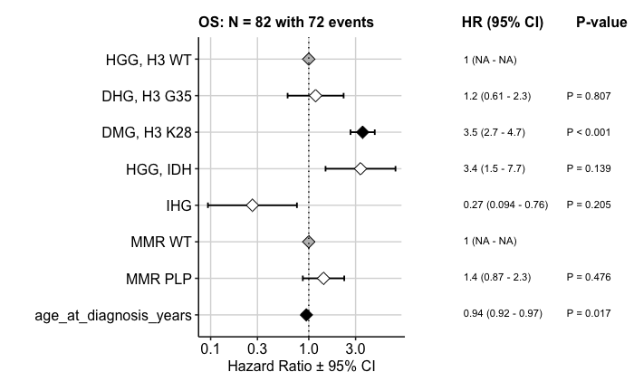

```r
add_os_model <- fit_save_model(hgg_hist,
                             "mol_sub_group+age_at_diagnosis_years+MMR_variant",
                                 file.path(results_dir, "coxph_hgg_OS_subtype_age_MMRvariant.RDS"),
                                 "multivariate",
                                 years_col = "OS_years",
                                 status_col = "OS_status")

os_forest_plot <- plotForest(readRDS(file.path(results_dir, "coxph_hgg_OS_subtype_age_MMRvariant.RDS")))
ggsave(file.path(plots_dir, "forest_hgg_OS_subtype_age_mmrPLP.pdf"),
       os_forest_plot,
       width = 8, height = 3, units = "in",
       device = "pdf")
```

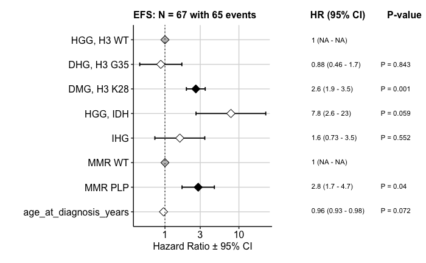

```r
add_efs_model <- fit_save_model(hgg_hist,
                             "mol_sub_group+age_at_diagnosis_years+MMR_variant",
                             file.path(results_dir, "coxph_hgg_EFS_subtype_age_MMRvariant.RDS"),
                             "multivariate",
                             years_col = "EFS_years",
                             status_col = "EFS_status")

efs_forest_plot <- plotForest(readRDS(file.path(results_dir, "coxph_hgg_EFS_subtype_age_MMRvariant.RDS")))
ggsave(file.path(plots_dir, "forest_hgg_EFS_subtype_age_mmrPLP.pdf"),
       efs_forest_plot,
       width = 8, height = 3, units = "in",
       device = "pdf")
```

Write HGG sample histologies with MMR germline variants to output

```r
mmr_hist <- hgg_hist %>%
    filter(grepl("MMR PLP", MMR_variant)) %>%
    select(Kids_First_Participant_ID, Kids_First_Biospecimen_ID_normal,
           plot_group, molecular_subtype, mol_sub_group, OS_days, OS_status, EFS_days, EFS_status,
           extent_of_tumor_resection) %>%
    rename("Kids_First_Biospecimen_ID" = Kids_First_Biospecimen_ID_normal) %>%
    left_join(all_plp[,c("Kids_First_Biospecimen_ID", "Hugo_Symbol", "L-LP_Call_final", "Reasoning_for_call", "HGVS.c", "HGVS.p")]) %>%
    filter(Hugo_Symbol %in% mmr_genes)
```

Define vector of BRCA/BRCA-interacting genes

```r
brca_bs <- all_plp %>%
      filter(grepl("BRCA|BARD1|BRIP1|ATM|CHEK2|RAD51|PALB2", Hugo_Symbol) & !grepl("RAD51C", Hugo_Symbol)) %>%
      pull(Kids_First_Biospecimen_ID) %>%
      unique()
```

Create column indicating presence/absence of BRCA variant

```r
hgg_hist <- hgg_hist %>%
  mutate(brca_variant = case_when(
    Kids_First_Biospecimen_ID_normal %in% brca_bs ~ "BRCA PLP",
    TRUE ~ "BRCA WT"
  ))  %>%
  mutate(brca_variant = factor(brca_variant,
                                   c("BRCA WT",
                                     "BRCA PLP")))
```

Run KM survival models by BRCA variant status, and plot results

```r
kap_os <- survival_analysis(
  metadata  = hgg_hist,
  ind_var = "brca_variant",
  test = "kap.meier",
  metadata_sample_col = "Kids_First_Biospecimen_ID_normal",
  days_col = "OS_days",
  status_col = "OS_status"
  )
```

```
Testing model: survival::Surv(OS_days, OS_status) ~ brca_variant with kap.meier
```

```r
kap_efs <- survival_analysis(
  metadata  = hgg_hist,
  ind_var = "brca_variant",
  test = "kap.meier",
  metadata_sample_col = "Kids_First_Biospecimen_ID_normal",
  days_col = "EFS_days",
  status_col = "EFS_status"
  )
```

```
Testing model: survival::Surv(EFS_days, EFS_status) ~ brca_variant with kap.meier
```

```r
km_plot <- plotKM(model = list(kap_os, kap_efs),
                    variable = "brca_variant",
                    combined = T,
                    title = "HGG")
```

|  | t | l | b | r |
| --- | --- | --- | --- | --- |
| 1: | 1 | 1 | 1 | 1 |
| 2: | 1 | 2 | 1 | 2 |

```r
ggsave(km_brca_output_pdf, km_plot,
       width = 10, height = 6, units = "in",
       device = "pdf")
```

Run coxph models with covariates `mol_sub_group`, `age_at_diagnosis_years`, and `brca_variant`

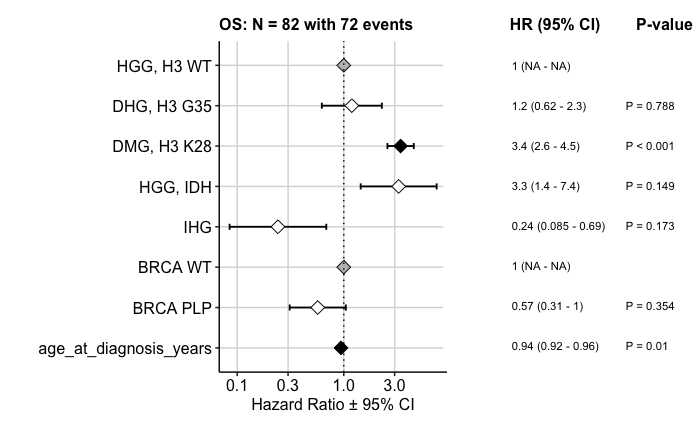

```r
add_os_model <- fit_save_model(hgg_hist,
                             "mol_sub_group+age_at_diagnosis_years+brca_variant",
                                 file.path(results_dir, "coxph_hgg_OS_subtype_BRCAvariant.RDS"),
                                 "multivariate",
                                 years_col = "OS_years",
                                 status_col = "OS_status")

os_forest_plot <- plotForest(readRDS(file.path(results_dir, "coxph_hgg_OS_subtype_BRCAvariant.RDS")))
ggsave(file.path(plots_dir, "forest_hgg_OS_subtype_brcaPLP.pdf"),
       os_forest_plot,
       width = 8, height = 3, units = "in",
       device = "pdf")
```

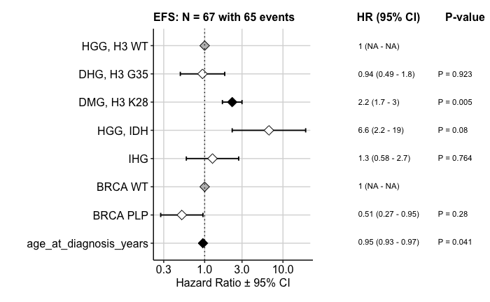

```r
add_efs_model <- fit_save_model(hgg_hist,
                             "mol_sub_group+age_at_diagnosis_years+brca_variant",
                             file.path(results_dir, "coxph_hgg_EFS_subtype_BRCAvariant.RDS"),
                             "multivariate",
                             years_col = "EFS_years",
                             status_col = "EFS_status")

efs_forest_plot <- plotForest(readRDS(file.path(results_dir, "coxph_hgg_EFS_subtype_BRCAvariant.RDS")))
ggsave(file.path(plots_dir, "forest_hgg_EFS_subtype_brcaPLP.pdf"),
       efs_forest_plot,
       width = 8, height = 3, units = "in",
       device = "pdf")
```